# Exercise 13.7

Kári Hlynsson

April 2024

This problem makes use of the `Carseats` data set in the `ISLR2` package.

## Part (a)

For each quantitative variable in the data set besides `Sales`, fit a linear model to predict `Sales` using that quantitative variable. Report the $p$-values associated with the coefficients for the variables. That is, for each model of the form $Y = \beta_0 + \beta_1 X + \epsilon$, report the $p$-value associated with the coefficient $\beta_1$. Here, $Y$ represents `Sales` and $X$ represents one of the other quantitative variables.

### Solution.

We start by importing the `Carseats` data set and selecting the quantitative predictors which are stored in the variable `vars`:

```r
library(ISLR2)
data(Carseats)

vars <- names(
  which(sapply(Carseats, is.numeric) & names(Carseats) != "Sales")
) |> sort()
```

Now we fit a series of simple linear models $\mathcal M_1, \ldots, \mathcal M_p$ of `Sales` ($Y$) against each of the quantitative covariates $X_1, \ldots, X_p$ contained in `vars`. In other words, we fit the series of models
$$\begin{align*}
\mathcal M_1: Y &= \beta_{01} + \beta_{11} X_1 + \epsilon \\
&\vdots \\
\mathcal M_p: Y &= \beta_{0p} + \beta_{1p} X_p + \epsilon,
\end{align*}$$
and investigate the value of the Wald test statistic $p_j$ associated with the effect size $\beta_{1j}$ in model $\mathcal M_j$, each of which corresponds to a hypotheses test of the form
$$H_0: \beta_{1j} = 0, \quad H_1: \beta_{1j} \neq 0.$$
The later parts of this exercise will revolve around different methods for controlling Type I error in light of multiple testing. Recover the $p$-values:

```r
pvals <- sapply(vars, function(var) {
  fit <- lm(as.formula(paste0("Sales ~ ", var)), data = Carseats)
  pval <- summary(fit)$coefficients[2, 4]
  return(pval)
})

pvals
```

```
##  Advertising          Age    CompPrice    Education       Income   Population        Price
## 4.377677e-08 2.788950e-06 2.009398e-01 2.999442e-01 2.309670e-03 3.139816e-01 7.618187e-21
```

Notice that the $p$-values for predictors `Advertising`, `Age`, `Income` and `Price` are markedly small compared to the other values. This is reinforced by the visualisation of the various predictors against `Sales`. Indeed, in the case of the four variables, there is seemingly some discernible linearity in the data.

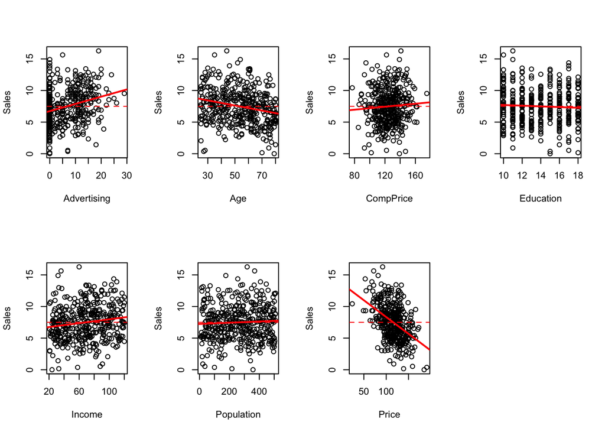

```r
par(mfrow = c(2, 4))
for (var in vars) {
  plot(Carseats[[var]], Carseats[["Sales"]], xlab = paste(var), ylab = "Sales")
  abline(lm(Carseats[["Sales"]] ~ Carseats[[var]]),
    lwd = 2, col = "red"
  )
  abline(h = mean(Carseats[["Sales"]]), lty = 2, col = "red")
}
```

## Part (b)

Suppose we control the Type I error at level $\alpha = 0.05$ for the $p$-values obtained in (a). Which null hypotheses do we reject?

### Solution.

This is the simple case where in a manner analogous to single hypothesis testing we simply determine whether $p_j < \alpha$ sequentially irrespective of the number of tests performed. If $p_j < \alpha$ we reject the null hypothesis $H_0$ in model $\mathcal M_j$ in favour of the claim that $\beta_{1j} \neq 0$, i.e. that the effect size of the $j$th covariate in a simple linear model is distinct from zero.

Doing this in `R` amounts to simply filtering the `pvals` vector for values below $\alpha = 0.05$:

```r
names(which(pvals < 0.05))
```

```
## [1] "Advertising" "Age"         "Income"      "Price"
```

The significant tests are for the predictors `Advertising`, `Age`, `Income` and `Price`. (Compare with output in part (a).)

## Part (c)

Now suppose we control the FWER at level 0.05 for the $p$-values. Which null hypotheses do we reject?

### Solution.

We will employ two methods that are popular for controlling the FWER, namely the Bonferroni correction and the Holm Step-Down method, both of which are described in detail in Chapter 13. Start by making the adjustments to `pvals`:

```r
p_bonf <- p.adjust(pvals, method = "bonferroni")
p_bonf
```

```
##  Advertising          Age    CompPrice    Education       Income   Population        Price
## 3.064374e-07 1.952265e-05 1.000000e+00 1.000000e+00 1.616769e-02 1.000000e+00 5.332731e-20
```

```r
p_holm <- p.adjust(pvals, method = "holm")
p_holm
```

```
##  Advertising          Age    CompPrice    Education       Income   Population        Price
## 2.626606e-07 1.394475e-05 6.028195e-01 6.028195e-01 9.238682e-03 6.028195e-01 5.332731e-20
```

Indeed, we see that the $p$-values for the four significant covariates from (b) remain significant.

```r
# Bonferroni
names(which(p_bonf < 0.05))
```

```
## [1] "Advertising" "Age"         "Income"      "Price"
```

```r
# Holm
names(which(p_holm < 0.05))
```

```
## [1] "Advertising" "Age"         "Income"      "Price"
```

## Part (d)

Finally, suppose we control the FDR at level 0.2 for the $p$-values. Which null hypotheses do we reject?

### Solution.

Lastly we employ methods to control the false discovery rate, or FDR. One way with which we can do this is using the Benjamini-Hochberg procedure, which is designated as `bh` or `fdr` in the `method` variable in the `p.adjust()` function.

```r
# Benjamini-Hochberg
p_bh <- p.adjust(pvals, method = "fdr")
p_bh
```

```
##  Advertising          Age    CompPrice    Education       Income   Population        Price
## 1.532187e-07 6.507550e-06 2.813158e-01 3.139816e-01 4.041923e-03 3.139816e-01 5.332731e-20
```

Let’s see which of the predictors are significant using the Benjamini-Hochberg adjusted $p$-values:

```r
names(which(p_bh < 0.2))
```

```
## [1] "Advertising" "Age"         "Income"      "Price"
```

The results are not very novel. The same four predictors, namely `Advertising`, `Age`, `Income` and `Price` are claimed to have significantly non-zero effect sizes.